# QTM 151 - Quiz 2

## Try to submit as an HTML file

Print your name below

```python
# Write your answer here
Ahshar Brown
```

This quiz is open book

- You can use the lecture notes
- You will get partial credit for attempting the questions
- To get full credit, the code should run as intended
- You should NOT communicate with other students

Print the following message:

"I will abide by Emory's code of conduct"

```python
# Write your answer here:
"I will abide by Emory's code of conduct"
```

Import the libraries "numpy", "matplotlib.pyplot",  
"pandas", "statsmodels.api" and "statsmodels.formula.api"

```python
# Write your answer here
import numpy as np
import pandas as pd
import matplotlib.pyplot as plt
import statsmodels.api as sm
import statsmodels.formula.api as smf
```

Read the dataset "data_quiz/fifa23_players_basic.csv"

- It's a dataset on professional soccer players
- Rows correspond to players (18,539)
- Columns contain attributes of players (32)
- Try to view the dataset before starting

to get a sense of its content

```python
# Write your own code
dataset = pd.read_csv("data_quiz/fifa23_players_basic.csv")
display(dataset)
```

|  | Unnamed: 0 | Known As | Full Name | Overall | Potential | Value(in Euro) | Positions Played | Best Position | Nationality | Image Link | ... | Preferred Foot | Weak Foot Rating | Skill Moves | International Reputation | National Team Name | National Team Image Link | National Team Position | National Team Jersey Number | Attacking Work Rate | Defensive Work Rate |
| --- | --- | --- | --- | --- | --- | --- | --- | --- | --- | --- | --- | --- | --- | --- | --- | --- | --- | --- | --- | --- | --- |
| 0 | 0 | L. Messi | Lionel Messi | 91 | 91 | 54000000 | RW | CAM | Argentina | https://cdn.sofifa.net/players/158/023/23_60.png | ... | Left | 4 | 4 | 5 | Argentina | https://cdn.sofifa.net/flags/ar.png | RW | 10 | Low | Low |
| 1 | 1 | K. Benzema | Karim Benzema | 91 | 91 | 64000000 | CF,ST | CF | France | https://cdn.sofifa.net/players/165/153/23_60.png | ... | Right | 4 | 4 | 4 | France | https://cdn.sofifa.net/flags/fr.png | ST | 19 | Medium | Medium |
| 2 | 2 | R. Lewandowski | Robert Lewandowski | 91 | 91 | 84000000 | ST | ST | Poland | https://cdn.sofifa.net/players/188/545/23_60.png | ... | Right | 4 | 4 | 5 | Poland | https://cdn.sofifa.net/flags/pl.png | ST | 9 | High | Medium |
| 3 | 3 | K. De Bruyne | Kevin De Bruyne | 91 | 91 | 107500000 | CM,CAM | CM | Belgium | https://cdn.sofifa.net/players/192/985/23_60.png | ... | Right | 5 | 4 | 4 | Belgium | https://cdn.sofifa.net/flags/be.png | RF | 7 | High | High |
| 4 | 4 | K. Mbappé | Kylian Mbappé | 91 | 95 | 190500000 | ST,LW | ST | France | https://cdn.sofifa.net/players/231/747/23_60.png | ... | Right | 4 | 5 | 4 | France | https://cdn.sofifa.net/flags/fr.png | ST | 10 | High | Low |
| ... | ... | ... | ... | ... | ... | ... | ... | ... | ... | ... | ... | ... | ... | ... | ... | ... | ... | ... | ... | ... | ... |
| 18534 | 18534 | D. Collins | Darren Collins | 47 | 56 | 110000 | ST,RM | CAM | Republic of Ireland | https://cdn.sofifa.net/players/243/725/23_60.png | ... | Right | 3 | 2 | 1 | - | - | - | - | Medium | Medium |
| 18535 | 18535 | Yang Dejiang | Dejiang Yang | 47 | 57 | 90000 | CDM | CDM | China PR | https://cdn.sofifa.net/players/261/933/23_60.png | ... | Right | 3 | 2 | 1 | - | - | - | - | Medium | Medium |
| 18536 | 18536 | L. Mullan | Liam Mullan | 47 | 67 | 130000 | CM | RM | Northern Ireland | https://cdn.sofifa.net/players/267/823/23_60.png | ... | Right | 3 | 2 | 1 | - | - | - | - | High | Medium |
| 18537 | 18537 | D. McCallion | Daithí McCallion | 47 | 61 | 100000 | CB | CB | Republic of Ireland | https://cdn.sofifa.net/players/267/824/23_60.png | ... | Right | 3 | 2 | 1 | - | - | - | - | Medium | Medium |
| 18538 | 18538 | N. Rabha | Nabin Rabha | 47 | 50 | 60000 | LB | LB | India | https://cdn.sofifa.net/players/261/424/23_60.png | ... | Left | 3 | 2 | 1 | - | - | - | - | Medium | Medium |

18539 rows × 33 columns

(a) Use queries + global variables

- Subset the players whose value of the column "On Loan" is "YES"

and store it in a new dataset

- How many players are on loan?

HINT: Remember that there is a special syntax for  
when the column names have spaces (see Lecture 10)  
and when the value is a string.  
Reference the column as `` `On Loan` `` inside .query()

```python
# Write your own code
dataset["new variable"] = dataset["On Loan"]
data_spacesthreshold = dataset.query("`new variable` == 'YES' ")
display(data_spacesthreshold)

players_on_loan_count = data_spacesthreshold.shape[0]
print(f"Number of players on loan: {players_on_loan_count}")
```

|  | Unnamed: 0 | Known As | Full Name | Overall | Potential | Value(in Euro) | Positions Played | Best Position | Nationality | Image Link | ... | National Team Name | National Team Image Link | National Team Position | National Team Jersey Number | Attacking Work Rate | Defensive Work Rate | new variable | player_classification | p_estimated | random_var |
| --- | --- | --- | --- | --- | --- | --- | --- | --- | --- | --- | --- | --- | --- | --- | --- | --- | --- | --- | --- | --- | --- |
| 45 | 45 | R. Lukaku | Romelu Lukaku | 86 | 86 | 68000000 | ST | ST | Belgium | https://cdn.sofifa.net/players/192/505/23_60.png | ... | Belgium | https://cdn.sofifa.net/flags/be.png | ST | 9 | Medium | Low | YES | Non Top Performer | 69.715462 | 0.340884 |
| 154 | 154 | Angeliño | José Ángel Esmoris Tasende | 83 | 85 | 42000000 | LWB,LM | LM | Spain | https://cdn.sofifa.net/players/220/651/23_60.png | ... | - | https://cdn.sofifa.net/flags/es.png | - | - | High | High | YES | Non Top Performer | 71.099875 | 0.597097 |
| 191 | 191 | A. Griezmann | Antoine Griezmann | 83 | 83 | 30500000 | ST,CF,RW | CAM | France | https://cdn.sofifa.net/players/194/765/23_60.png | ... | France | https://cdn.sofifa.net/flags/fr.png | CAM | 7 | Medium | Medium | YES | Non Top Performer | 69.023256 | 0.851613 |
| 204 | 204 | M. Locatelli | Manuel Locatelli | 82 | 86 | 40000000 | CDM,CM | CM | Italy | https://cdn.sofifa.net/players/222/077/23_60.png | ... | Italy | https://cdn.sofifa.net/flags/it.png | SUB | 5 | Medium | High | YES | Non Top Performer | 71.445978 | 0.287641 |
| 205 | 205 | R. Gosens | Robin Gosens | 82 | 82 | 29500000 | LWB,LM | LWB | Germany | https://cdn.sofifa.net/players/223/697/23_60.png | ... | Germany | https://cdn.sofifa.net/flags/de.png | SUB | 16 | High | Medium | YES | Non Top Performer | 70.407669 | 0.591283 |
| ... | ... | ... | ... | ... | ... | ... | ... | ... | ... | ... | ... | ... | ... | ... | ... | ... | ... | ... | ... | ... | ... |
| 18206 | 18206 | Kim Jeong hoon | Jeong Hoon Kim | 52 | 62 | 160000 | GK | GK | Korea Republic | https://cdn.sofifa.net/players/252/662/23_60.png | ... | - | - | - | - | Medium | Medium | YES | Non Top Performer | 72.484288 | 0.316160 |
| 18283 | 18283 | E. Taylor | Ellis Taylor | 51 | 65 | 140000 | RM,LB | LM | England | https://cdn.sofifa.net/players/263/990/23_60.png | ... | - | https://cdn.sofifa.net/flags/gb-eng.png | - | - | Medium | Medium | YES | Non Top Performer | 73.176494 | 0.614991 |
| 18343 | 18343 | Yoon Suk Ju | Suk Ju Yoon | 50 | 65 | 110000 | CDM | CDM | Korea Republic | https://cdn.sofifa.net/players/261/121/23_60.png | ... | - | - | - | - | Medium | Medium | YES | Non Top Performer | 72.830391 | 0.255105 |
| 18390 | 18390 | S. Ghidotti | Simone Ghidotti | 50 | 57 | 80000 | GK | GK | Italy | https://cdn.sofifa.net/players/270/756/23_60.png | ... | - | https://cdn.sofifa.net/flags/it.png | - | - | Medium | Medium | YES | Non Top Performer | 72.138184 | 0.198234 |
| 18431 | 18431 | D. Robson | David Robson | 50 | 63 | 100000 | GK | GK | Wales | https://cdn.sofifa.net/players/258/888/23_60.png | ... | - | https://cdn.sofifa.net/flags/gb-wls.png | - | - | Medium | Medium | YES | Non Top Performer | 72.830391 | 0.801719 |

1229 rows × 37 columns

```
Number of players on loan: 1229
```

(b) Create a function and apply it to a column

Step 1:

- Define a function with a parameter "Overall"
- If "Overall > 90", classification = "Top Performer"
- If "Overall <= 90", classification = "Non Top-Performer"
- The function returns "classification"

Step 2:

- Extract the column "Overall" in the dataset

(be carefeful to write the "O" capitalized)

- Create a new variable called "player_classification"

to assign each player to the correct classification

HINT: Use the ".apply()" function

```python
# Write your own code
Overall = 100
#Overall = 76
def my_function(Overall):
    if Overall > 90:
        classification = "Top Performer"
        return classification
    elif Overall <= 90:
        classification = "Non Top Performer"
        return classification
result = my_function(Overall)

print(result)

column = dataset['Overall']
print(column)
dataset['player_classification'] = dataset['Overall'].apply(my_function)
print(dataset[['Overall', 'player_classification']])
```

```
Top Performer
0        91
1        91
2        91
3        91
4        91
         ..
18534    47
18535    47
18536    47
18537    47
18538    47
Name: Overall, Length: 18539, dtype: int64
       Overall player_classification
0           91         Top Performer
1           91         Top Performer
2           91         Top Performer
3           91         Top Performer
4           91         Top Performer
...        ...                   ...
18534       47     Non Top Performer
18535       47     Non Top Performer
18536       47     Non Top Performer
18537       47     Non Top Performer
18538       47     Non Top Performer

[18539 rows x 2 columns]
```

(c) Use sorting + ".iloc[]"

The varable "Joined On" shows the date in which each player joined FIFA

- Use ".sort_values()" to order the "Joined On" column

from earlier data to later date

- Get a subset with the 6 players in the dataset

who joined FIFA earliest

- From this subset, display the year in which they joined

by displaying the column "Joined On"

```python
# Write your own code
joined_On_Dates = dataset.sort_values(by = "Joined On", ascending = True)
display(joined_On_Dates)

earliest_6_players = joined_On_Dates.iloc[0:6, :]
display(earliest_6_players)

joined_years = earliest_6_players["Joined On"]
display(joined_years)
```

|  | Unnamed: 0 | Known As | Full Name | Overall | Potential | Value(in Euro) | Positions Played | Best Position | Nationality | Image Link | ... | National Team Name | National Team Image Link | National Team Position | National Team Jersey Number | Attacking Work Rate | Defensive Work Rate | new variable | player_classification | p_estimated | random_var |
| --- | --- | --- | --- | --- | --- | --- | --- | --- | --- | --- | --- | --- | --- | --- | --- | --- | --- | --- | --- | --- | --- |
| 8586 | 8586 | D. Lewington | Dean Lewington | 66 | 66 | 150000 | CB | CDM | England | https://cdn.sofifa.net/players/138/830/23_60.png | ... | - | https://cdn.sofifa.net/flags/gb-eng.png | - | - | High | Medium | - | Non Top Performer | 66.600534 | 0.673697 |
| 10877 | 10877 | P. Karlsson | Per Karlsson | 64 | 64 | 100000 | CB | CB | Sweden | https://cdn.sofifa.net/players/176/717/23_60.png | ... | - | https://cdn.sofifa.net/flags/se.png | - | - | Low | High | - | Non Top Performer | 67.292740 | 0.580627 |
| 4324 | 4324 | I. Khune | Itumeleng Khune | 70 | 70 | 180000 | GK | GK | South Africa | https://cdn.sofifa.net/players/165/247/23_60.png | ... | - | https://cdn.sofifa.net/flags/za.png | - | - | Medium | Medium | - | Non Top Performer | 67.638843 | 0.026812 |
| 11056 | 11056 | Cai Huikang | Huikang Cai | 64 | 64 | 400000 | CDM,CM | CB | China PR | https://cdn.sofifa.net/players/224/608/23_60.png | ... | - | - | - | - | Low | High | - | Non Top Performer | 68.677153 | 0.166264 |
| 10360 | 10360 | L. Stevenson | Lewis Stevenson | 65 | 65 | 250000 | LB | LB | Scotland | https://cdn.sofifa.net/players/175/316/23_60.png | ... | - | https://cdn.sofifa.net/flags/gb-sct.png | - | - | High | High | - | Non Top Performer | 67.984947 | 0.660085 |
| ... | ... | ... | ... | ... | ... | ... | ... | ... | ... | ... | ... | ... | ... | ... | ... | ... | ... | ... | ... | ... | ... |
| 11623 | 11623 | K. Tapoko | Kevin Tapoko | 64 | 65 | 575000 | CDM,CM | CDM | France | https://cdn.sofifa.net/players/211/484/23_60.png | ... | - | https://cdn.sofifa.net/flags/fr.png | - | - | Medium | Medium | - | Non Top Performer | 70.061565 | 0.051990 |
| 3551 | 3551 | P. Lasne | Paul Lasne | 72 | 72 | 1200000 | CDM,CM | CDM | France | https://cdn.sofifa.net/players/192/242/23_60.png | ... | - | https://cdn.sofifa.net/flags/fr.png | - | - | Medium | High | - | Non Top Performer | 68.331050 | 0.951984 |
| 11618 | 11618 | V. Dican | Victor Dican | 64 | 73 | 1200000 | CB,CDM | CB | Romania | https://cdn.sofifa.net/players/266/792/23_60.png | ... | - | https://cdn.sofifa.net/flags/ro.png | - | - | Medium | Medium | - | Non Top Performer | 72.484288 | 0.174475 |
| 3538 | 3538 | Édundo Oliveira | Éder Marvin Oliveira Simão | 72 | 72 | 1900000 | CB | CB | Brazil | https://cdn.sofifa.net/players/230/389/23_60.png | ... | - | https://cdn.sofifa.net/flags/br.png | - | - | Medium | Medium | - | Non Top Performer | 69.369359 | 0.363220 |
| 3152 | 3152 | João Bruinheira | João Fabrício Bruinheira Salvador | 72 | 72 | 400000 | GK | GK | Brazil | https://cdn.sofifa.net/players/230/525/23_60.png | ... | - | https://cdn.sofifa.net/flags/br.png | - | - | Medium | Medium | - | Non Top Performer | 67.984947 | 0.831718 |

18539 rows × 37 columns

|  | Unnamed: 0 | Known As | Full Name | Overall | Potential | Value(in Euro) | Positions Played | Best Position | Nationality | Image Link | ... | National Team Name | National Team Image Link | National Team Position | National Team Jersey Number | Attacking Work Rate | Defensive Work Rate | new variable | player_classification | p_estimated | random_var |
| --- | --- | --- | --- | --- | --- | --- | --- | --- | --- | --- | --- | --- | --- | --- | --- | --- | --- | --- | --- | --- | --- |
| 8586 | 8586 | D. Lewington | Dean Lewington | 66 | 66 | 150000 | CB | CDM | England | https://cdn.sofifa.net/players/138/830/23_60.png | ... | - | https://cdn.sofifa.net/flags/gb-eng.png | - | - | High | Medium | - | Non Top Performer | 66.600534 | 0.673697 |
| 10877 | 10877 | P. Karlsson | Per Karlsson | 64 | 64 | 100000 | CB | CB | Sweden | https://cdn.sofifa.net/players/176/717/23_60.png | ... | - | https://cdn.sofifa.net/flags/se.png | - | - | Low | High | - | Non Top Performer | 67.292740 | 0.580627 |
| 4324 | 4324 | I. Khune | Itumeleng Khune | 70 | 70 | 180000 | GK | GK | South Africa | https://cdn.sofifa.net/players/165/247/23_60.png | ... | - | https://cdn.sofifa.net/flags/za.png | - | - | Medium | Medium | - | Non Top Performer | 67.638843 | 0.026812 |
| 11056 | 11056 | Cai Huikang | Huikang Cai | 64 | 64 | 400000 | CDM,CM | CB | China PR | https://cdn.sofifa.net/players/224/608/23_60.png | ... | - | - | - | - | Low | High | - | Non Top Performer | 68.677153 | 0.166264 |
| 10360 | 10360 | L. Stevenson | Lewis Stevenson | 65 | 65 | 250000 | LB | LB | Scotland | https://cdn.sofifa.net/players/175/316/23_60.png | ... | - | https://cdn.sofifa.net/flags/gb-sct.png | - | - | High | High | - | Non Top Performer | 67.984947 | 0.660085 |
| 11768 | 11768 | Wang Shenchao | Shenchao Wang | 64 | 64 | 275000 | CB,RM | CB | China PR | https://cdn.sofifa.net/players/224/604/23_60.png | ... | China PR | - | RB | 4 | High | High | - | Non Top Performer | 68.331050 | 0.939978 |

6 rows × 37 columns

```
8586     2002
10877    2003
4324     2004
11056    2005
10360    2005
11768    2005
Name: Joined On, dtype: int64
```

(d) Regression function

- Run a regression of "Potential" (left-hand side) on "Age" (right-hand side)
- What are the values of the coefficients?

[HINT: Use the commands `smf.ols()` and `.fit()` and `.params`  
from Lecture 11 ]

```
Intercept: 79.7524538648746
Coefficient (Slope): -0.3461031564434816
```

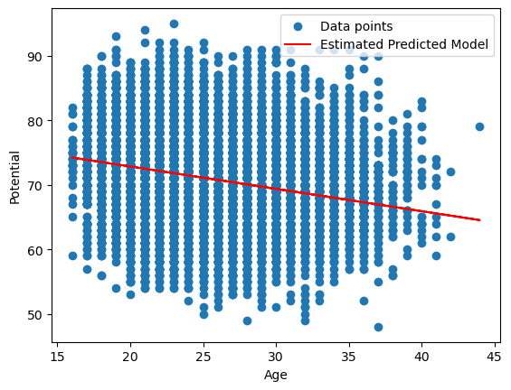

```python
# Write your own code
model = smf.ols(formula='Potential ~ Age', data=dataset)
results = model.fit()

b_list = results.params
print("Intercept:", b_list[0])
print("Coefficient (Slope):", b_list[1])

dataset["p_estimated"] = b_list[0] + b_list[1] * dataset["Age"]

plt.scatter(x=dataset["Age"], y=dataset["Potential"], label="Data points")
plt.plot(dataset["Age"], dataset["p_estimated"], color='red', label="Estimated Predicted Model")
plt.xlabel('Age')
plt.ylabel('Potential')
plt.legend()
plt.show()
```

(e) Split a dataset into subsets

- Store the total number of rows of the dataset in a variable called `n`
- Create a new variable called `random_var` drawn from a

uniform distribution between 0 and 1 with size `n`

- Use .query() to subset all observations with `random_var <0.5`.

store it in a new dataset called "data0"

- Use .query() to subset all observations with `random_var >= 0.5`.

store it in a new dataset called "data1"

[HINT: See Lecture 2 for how to generate a uniform random variable]

```python
# Write your own code
n = len(dataset)

dataset['random_var'] = np.random.uniform(0, 1, size=n)
data0 = dataset.query('random_var < 0.5')
data1 = dataset.query('random_var >= 0.5')

print("random_var < 0.5 (data0):")
print(data0)
display(data0)

print("random_var >= 0.5 (data1):")
print(data1)
display(data1)
```

```
random_var < 0.5 (data0):
       Unnamed: 0           Known As                     Full Name  Overall  \
3               3       K. De Bruyne               Kevin De Bruyne       91
4               4          K. Mbappé                 Kylian Mbappé       91
5               5           M. Salah                 Mohamed Salah       90
8               8  Cristiano Ronaldo  C. Ronaldo dos Santos Aveiro       90
9               9        V. van Dijk               Virgil van Dijk       90
...           ...                ...                           ...      ...
18527       18527        Liu Junxian                   Junxian Liu       48
18530       18530             S. Bag                     Sajal Bag       48
18531       18531           Liao Wei                      Wei Liao       48
18533       18533          Pi Ziyang                     Ziyang Pi       47
18534       18534         D. Collins                Darren Collins       47

       Potential  Value(in Euro) Positions Played Best Position  \
```

[output cut: 78 more lines]

|  | Unnamed: 0 | Known As | Full Name | Overall | Potential | Value(in Euro) | Positions Played | Best Position | Nationality | Image Link | ... | National Team Name | National Team Image Link | National Team Position | National Team Jersey Number | Attacking Work Rate | Defensive Work Rate | new variable | player_classification | p_estimated | random_var |
| --- | --- | --- | --- | --- | --- | --- | --- | --- | --- | --- | --- | --- | --- | --- | --- | --- | --- | --- | --- | --- | --- |
| 3 | 3 | K. De Bruyne | Kevin De Bruyne | 91 | 91 | 107500000 | CM,CAM | CM | Belgium | https://cdn.sofifa.net/players/192/985/23_60.png | ... | Belgium | https://cdn.sofifa.net/flags/be.png | RF | 7 | High | High | - | Top Performer | 69.023256 | 0.414900 |
| 4 | 4 | K. Mbappé | Kylian Mbappé | 91 | 95 | 190500000 | ST,LW | ST | France | https://cdn.sofifa.net/players/231/747/23_60.png | ... | France | https://cdn.sofifa.net/flags/fr.png | ST | 10 | High | Low | - | Top Performer | 71.792081 | 0.423852 |
| 5 | 5 | M. Salah | Mohamed Salah | 90 | 90 | 115500000 | RW | RW | Egypt | https://cdn.sofifa.net/players/209/331/23_60.png | ... | - | - | - | - | High | Medium | - | Non Top Performer | 69.369359 | 0.001770 |
| 8 | 8 | Cristiano Ronaldo | C. Ronaldo dos Santos Aveiro | 90 | 90 | 41000000 | ST | ST | Portugal | https://cdn.sofifa.net/players/020/801/23_60.png | ... | Portugal | https://cdn.sofifa.net/flags/pt.png | ST | 7 | High | Low | - | Non Top Performer | 66.946637 | 0.167894 |
| 9 | 9 | V. van Dijk | Virgil van Dijk | 90 | 90 | 98000000 | CB | CB | Netherlands | https://cdn.sofifa.net/players/203/376/23_60.png | ... | Netherlands | https://cdn.sofifa.net/flags/nl.png | CB | 4 | Medium | High | - | Non Top Performer | 69.369359 | 0.032409 |
| ... | ... | ... | ... | ... | ... | ... | ... | ... | ... | ... | ... | ... | ... | ... | ... | ... | ... | ... | ... | ... | ... |
| 18527 | 18527 | Liu Junxian | Junxian Liu | 48 | 58 | 110000 | ST | ST | China PR | https://cdn.sofifa.net/players/264/056/23_60.png | ... | - | - | - | - | Medium | Medium | - | Non Top Performer | 72.484288 | 0.182556 |
| 18530 | 18530 | S. Bag | Sajal Bag | 48 | 61 | 110000 | CM,RM | RM | India | https://cdn.sofifa.net/players/270/739/23_60.png | ... | - | - | - | - | Medium | Medium | - | Non Top Performer | 73.176494 | 0.022498 |
| 18531 | 18531 | Liao Wei | Wei Liao | 48 | 54 | 70000 | RM,LM | CDM | China PR | https://cdn.sofifa.net/players/257/691/23_60.png | ... | - | - | - | - | Medium | Medium | - | Non Top Performer | 71.792081 | 0.238783 |
| 18533 | 18533 | Pi Ziyang | Ziyang Pi | 47 | 60 | 110000 | CM | CAM | China PR | https://cdn.sofifa.net/players/269/066/23_60.png | ... | - | - | - | - | Medium | Medium | - | Non Top Performer | 73.176494 | 0.088824 |
| 18534 | 18534 | D. Collins | Darren Collins | 47 | 56 | 110000 | ST,RM | CAM | Republic of Ireland | https://cdn.sofifa.net/players/243/725/23_60.png | ... | - | - | - | - | Medium | Medium | - | Non Top Performer | 72.484288 | 0.114627 |

9273 rows × 37 columns

```
random_var >= 0.5 (data1):
       Unnamed: 0        Known As           Full Name  Overall  Potential  \
0               0        L. Messi        Lionel Messi       91         91
1               1      K. Benzema       Karim Benzema       91         91
2               2  R. Lewandowski  Robert Lewandowski       91         91
6               6     T. Courtois    Thibaut Courtois       90         91
7               7        M. Neuer        Manuel Neuer       90         90
...           ...             ...                 ...      ...        ...
18532       18532        H. Singh   Harmanpreet Singh       48         56
18535       18535    Yang Dejiang        Dejiang Yang       47         57
18536       18536       L. Mullan         Liam Mullan       47         67
18537       18537    D. McCallion    Daithí McCallion       47         61
18538       18538        N. Rabha         Nabin Rabha       47         50

       Value(in Euro) Positions Played Best Position          Nationality  \
```

[output cut: 78 more lines]

|  | Unnamed: 0 | Known As | Full Name | Overall | Potential | Value(in Euro) | Positions Played | Best Position | Nationality | Image Link | ... | National Team Name | National Team Image Link | National Team Position | National Team Jersey Number | Attacking Work Rate | Defensive Work Rate | new variable | player_classification | p_estimated | random_var |
| --- | --- | --- | --- | --- | --- | --- | --- | --- | --- | --- | --- | --- | --- | --- | --- | --- | --- | --- | --- | --- | --- |
| 0 | 0 | L. Messi | Lionel Messi | 91 | 91 | 54000000 | RW | CAM | Argentina | https://cdn.sofifa.net/players/158/023/23_60.png | ... | Argentina | https://cdn.sofifa.net/flags/ar.png | RW | 10 | Low | Low | - | Top Performer | 67.638843 | 0.703525 |
| 1 | 1 | K. Benzema | Karim Benzema | 91 | 91 | 64000000 | CF,ST | CF | France | https://cdn.sofifa.net/players/165/153/23_60.png | ... | France | https://cdn.sofifa.net/flags/fr.png | ST | 19 | Medium | Medium | - | Top Performer | 67.984947 | 0.870310 |
| 2 | 2 | R. Lewandowski | Robert Lewandowski | 91 | 91 | 84000000 | ST | ST | Poland | https://cdn.sofifa.net/players/188/545/23_60.png | ... | Poland | https://cdn.sofifa.net/flags/pl.png | ST | 9 | High | Medium | - | Top Performer | 68.331050 | 0.958446 |
| 6 | 6 | T. Courtois | Thibaut Courtois | 90 | 91 | 90000000 | GK | GK | Belgium | https://cdn.sofifa.net/players/192/119/23_60.png | ... | Belgium | https://cdn.sofifa.net/flags/be.png | GK | 1 | Medium | Medium | - | Non Top Performer | 69.369359 | 0.547412 |
| 7 | 7 | M. Neuer | Manuel Neuer | 90 | 90 | 13500000 | GK | GK | Germany | https://cdn.sofifa.net/players/167/495/23_60.png | ... | Germany | https://cdn.sofifa.net/flags/de.png | GK | 1 | Medium | Medium | - | Non Top Performer | 67.292740 | 0.682112 |
| ... | ... | ... | ... | ... | ... | ... | ... | ... | ... | ... | ... | ... | ... | ... | ... | ... | ... | ... | ... | ... | ... |
| 18532 | 18532 | H. Singh | Harmanpreet Singh | 48 | 56 | 100000 | ST | ST | India | https://cdn.sofifa.net/players/259/745/23_60.png | ... | - | - | - | - | Medium | Low | - | Non Top Performer | 72.830391 | 0.763763 |
| 18535 | 18535 | Yang Dejiang | Dejiang Yang | 47 | 57 | 90000 | CDM | CDM | China PR | https://cdn.sofifa.net/players/261/933/23_60.png | ... | - | - | - | - | Medium | Medium | - | Non Top Performer | 73.868700 | 0.771523 |
| 18536 | 18536 | L. Mullan | Liam Mullan | 47 | 67 | 130000 | CM | RM | Northern Ireland | https://cdn.sofifa.net/players/267/823/23_60.png | ... | - | - | - | - | High | Medium | - | Non Top Performer | 73.522597 | 0.530123 |
| 18537 | 18537 | D. McCallion | Daithí McCallion | 47 | 61 | 100000 | CB | CB | Republic of Ireland | https://cdn.sofifa.net/players/267/824/23_60.png | ... | - | - | - | - | Medium | Medium | - | Non Top Performer | 73.868700 | 0.825122 |
| 18538 | 18538 | N. Rabha | Nabin Rabha | 47 | 50 | 60000 | LB | LB | India | https://cdn.sofifa.net/players/261/424/23_60.png | ... | - | - | - | - | Medium | Medium | - | Non Top Performer | 71.099875 | 0.891031 |

9266 rows × 37 columns

(f) Create two overlapping histogram plots

- This question requires the two datasets you created in (e)
- Display the distribution of "Age" for "data0" and "data1" using

`plt.hist()`

- You will need to label the axes, and the title
- To get full points, plot the histograms with the option `alpha = 0.5`, e.g.

`plt.hist(x = ..., alpha = 0.5)`  
Make sure to substitute the corresponding "x" vector instead of `...`  
(The alpha option sets the transparency of the histogram )

Note: The goal of this question is to illustrate that random  
assignment produces very similar distributions between two groups

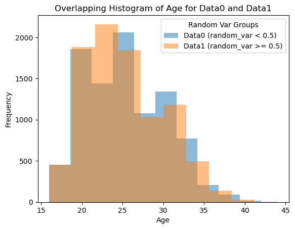

```python
# Write your own code
plt.hist(x=data0["Age"], alpha=0.5, label='Data0 (random_var < 0.5)')
plt.hist(x=data1["Age"], alpha=0.5, label='Data1 (random_var >= 0.5)')

plt.xlabel('Age')
plt.ylabel('Frequency')
plt.title('Overlapping Histogram of Age for Data0 and Data1')
plt.legend(title="Random Var Groups")
plt.show()
```